# PCIT-CoS-Waitlist RCT Paper 1: Child Sociability (NICHD), Controlling for ASD

Nancy Briggs

05 JAN 2021

### Child Sociability (NICHD) Adjusting for ASD

#### Descriptives

Raw Data

| asdcase | group | time | n | mean | sd | median | min | max |
| --- | --- | --- | --- | --- | --- | --- | --- | --- |
| 0 | 1 | 1 | 23 | 13.674 | 2.737 | 13.0 | 9 | 18 |
| 0 | 1 | 2 | 18 | 15.167 | 2.875 | 16.0 | 9 | 20 |
| 0 | 1 | 3 | 12 | 15.250 | 2.379 | 15.5 | 10 | 19 |
| 0 | 2 | 1 | 25 | 13.320 | 2.657 | 13.0 | 9 | 18 |
| 0 | 2 | 2 | 10 | 15.600 | 3.239 | 16.0 | 11 | 20 |
| 0 | 2 | 3 | 4 | 14.500 | 2.380 | 15.5 | 11 | 16 |
| 0 | 3 | 1 | 22 | 13.618 | 3.151 | 13.5 | 7 | 19 |
| 0 | 3 | 2 | 17 | 14.953 | 3.430 | 14.0 | 10 | 20 |
| 0 | 3 | 3 | 0 | NaN | NA | NA | Inf | -Inf |
| 1 | 1 | 1 | 6 | 11.167 | 3.061 | 11.5 | 7 | 16 |
| 1 | 1 | 2 | 3 | 15.667 | 2.309 | 17.0 | 13 | 17 |
| 1 | 1 | 3 | 4 | 13.500 | 2.517 | 14.0 | 10 | 16 |
| 1 | 2 | 1 | 3 | 11.667 | 4.619 | 9.0 | 9 | 17 |
| 1 | 2 | 2 | 2 | 15.500 | 3.536 | 15.5 | 13 | 18 |
| 1 | 2 | 3 | 0 | NaN | NA | NA | Inf | -Inf |
| 1 | 3 | 1 | 5 | 12.400 | 2.881 | 12.0 | 10 | 17 |
| 1 | 3 | 2 | 4 | 12.000 | 1.633 | 12.0 | 10 | 14 |
| 1 | 3 | 3 | 0 | NaN | NA | NA | Inf | -Inf |

Note:  
One person the Waitlist has a value at Follow Up. It has been set to missing.

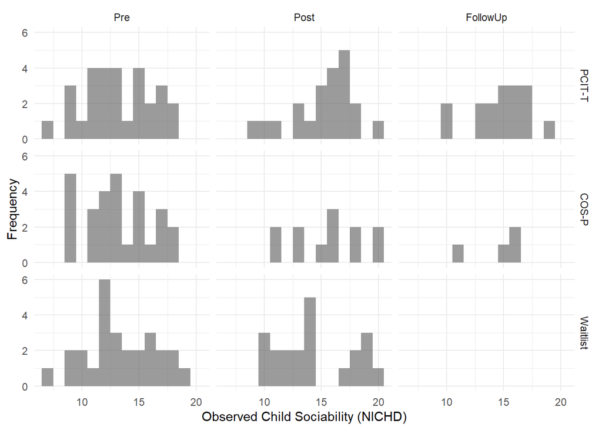

#### Model & Results

A linear mixed model with random effect for individual and fixed effects of group, time and the interaction was run. ASD status was then entered into the model as a main effect and then the 3-way interaction. Estimated marginal means were obtained, and contrasts specified to test Hypothesis 1 and Hypothesis 2.

```
## fixed-effect model matrix is rank deficient so dropping 1 column / coefficient
```

```
## fixed-effect model matrix is rank deficient so dropping 3 columns / coefficients
```

This is the ANOVA table for the model. p-values are likelihood ratio tests for adding the new term to the model just before. A p-value <0.05 indicates that adding that term results in better model fit. The most important p-value is the interaction p-value.

```
## refitting model(s) with ML (instead of REML)
```

[output not shown]

There is no evidence that ASD moderates the 2-way group*time interaction (the 3-way interaction p=0.887).

Model3, the model with Group*Time, adjusted by ASD will be the model I use for Estimated Means.

```r
summary(result3)
```

```
## Linear mixed model fit by REML. t-tests use Satterthwaite's method [
## lmerModLmerTest]
## Formula: outcome ~ asdcase + group * time + (1 | id)
##    Data: dat
##
## REML criterion at convergence: 754.2
##
## Scaled residuals:
##      Min       1Q   Median       3Q      Max
## -2.28302 -0.56180  0.06157  0.51949  1.99751
##
## Random effects:
##  Groups   Name        Variance Std.Dev.
##  id       (Intercept) 3.488    1.868
##  Residual             5.048    2.247
## Number of obs: 158, groups:  id, 86
##
## Fixed effects:
##              Estimate Std. Error       df t value Pr(>|t|)
## (Intercept)   13.5061     0.5639 119.3815  23.953  < 2e-16 ***
## asdcase1      -1.6961     0.7422  69.7863  -2.285  0.02534 *
## group2        -0.1695     0.7763 124.4959  -0.218  0.82757
## group3         0.1277     0.7804 124.9194   0.164  0.87027
## time2          1.8381     0.6640  73.2199   2.768  0.00713 **
## time3          1.6176     0.7331  76.6152   2.206  0.03035 *
## group2:time2   0.6787     1.0743  84.3413   0.632  0.52923
## group3:time2  -0.6560     0.9478  74.2706  -0.692  0.49099
## group2:time3  -0.9710     1.5511  96.3866  -0.626  0.53282
## ---
## Signif. codes:  0 '***' 0.001 '**' 0.01 '*' 0.05 '.' 0.1 ' ' 1
##
## Correlation of Fixed Effects:
##             (Intr) asdcs1 group2 group3 time2  time3  grp2:2 grp3:2
## asdcase1    -0.272
## group2      -0.699  0.097
## group3      -0.675  0.023  0.488
## time2       -0.475  0.035  0.341  0.337
## time3       -0.417 -0.016  0.304  0.304  0.400
## group2:tim2  0.300 -0.046 -0.437 -0.209 -0.619 -0.247
## group3:tim2  0.333 -0.027 -0.239 -0.494 -0.701 -0.280  0.434
## group2:tim3  0.191  0.029 -0.306 -0.143 -0.188 -0.473  0.278  0.132
## fit warnings:
## fixed-effect model matrix is rank deficient so dropping 1 column / coefficient
```

#### Estimated Means & Change

Estimated means for each Treatment and Time (adjusted by ASD status) are presented. In addition, within-group change between time points is presented with 95% CIs.

##### Group mean difference at each timepoint

Group Differences at Each Time Point

| Group Difference | Time | Mean | SE | t | p | adj p | Lower CL | Upper CL | Effect Size | Lower CL | Upper CL |
| --- | --- | --- | --- | --- | --- | --- | --- | --- | --- | --- | --- |
| 1 - 2 | 1 | 0.169 | 0.776 | 0.218 | 0.974 | 1.000 | -1.672 | 2.011 | 0.059 | -0.511 | 0.521 |
| 1 - 3 | 1 | -0.128 | 0.781 | -0.164 | 0.985 | 1.000 | -1.979 | 1.723 | -0.044 | -0.576 | 0.482 |
| 2 - 3 | 1 | -0.297 | 0.788 | -0.377 | 0.925 | 1.000 | -2.165 | 1.571 | -0.103 | -0.548 | 0.444 |
| 1 - 2 | 2 | -0.509 | 1.019 | -0.500 | 0.872 | 1.000 | -2.922 | 1.903 | -0.176 | -0.892 | 0.474 |
| 1 - 3 | 2 | 0.528 | 0.883 | 0.598 | 0.821 | 1.000 | -1.564 | 2.621 | 0.182 | -0.375 | 0.797 |
| 2 - 3 | 2 | 1.038 | 1.021 | 1.016 | 0.568 | 0.933 | -1.379 | 3.454 | 0.358 | -0.292 | 1.102 |
| 1 - 2 | 3 | 1.140 | 1.519 | 0.751 | 0.734 | 1.000 | -2.459 | 4.740 | 0.394 | -0.721 | 1.339 |
| 1 - 3 | 3 | NA | NA | NA | NA | NA | NA | NA | NA | NA | NA |
| 2 - 3 | 3 | NA | NA | NA | NA | NA | NA | NA | NA | NA | NA |

* Effect size scaled by pooled T1 SD  
† ES 95% Bootstrapped Percentile CI limits  
‡ If you want a positive ES (and it is calculated as negative), be sure to switch the signs and positions of the lower and upper CIs.

##### Change within each group

Within-Group Change and Effect Sizes

| Change | Group | Mean | SE | t | p | adj p | Lower CL | Upper CL | Effect Size | Lower CL | Upper CL |
| --- | --- | --- | --- | --- | --- | --- | --- | --- | --- | --- | --- |
| 1 - 2 | 1 | -1.838 | 0.666 | -2.762 | 0.019 | 0.021 | -3.428 | -0.248 | -0.635 | -1.127 | -0.186 |
| 1 - 3 | 1 | -1.618 | 0.736 | -2.198 | 0.077 | 0.092 | -3.374 | 0.139 | -0.559 | -1.072 | -0.027 |
| 2 - 3 | 1 | 0.221 | 0.769 | 0.287 | 0.956 | 1.000 | -1.618 | 2.059 | 0.076 | -0.410 | 0.633 |
| 1 - 2 | 2 | -2.517 | 0.849 | -2.963 | 0.011 | 0.011 | -4.538 | -0.495 | -0.869 | -1.404 | -0.285 |
| 1 - 3 | 2 | -0.647 | 1.380 | -0.469 | 0.886 | 1.000 | -3.926 | 2.633 | -0.223 | -1.178 | 0.697 |
| 2 - 3 | 2 | 1.870 | 1.439 | 1.300 | 0.399 | 0.591 | -1.556 | 5.296 | 0.646 | -0.376 | 1.600 |
| 1 - 2 | 3 | -1.182 | 0.678 | -1.743 | 0.196 | 0.255 | -2.801 | 0.437 | -0.408 | -0.880 | 0.045 |
| 1 - 3 | 3 | NA | NA | NA | NA | NA | NA | NA | NA | NA | NA |
| 2 - 3 | 3 | NA | NA | NA | NA | NA | NA | NA | NA | NA | NA |

* Effect size scaled by pooled T1 SD  
† ES 95% Bootstrapped Percentile CI limits  
‡ If you want a positive ES (and it is calculated as negative), be sure to switch the signs and positions of the lower and upper CIs.

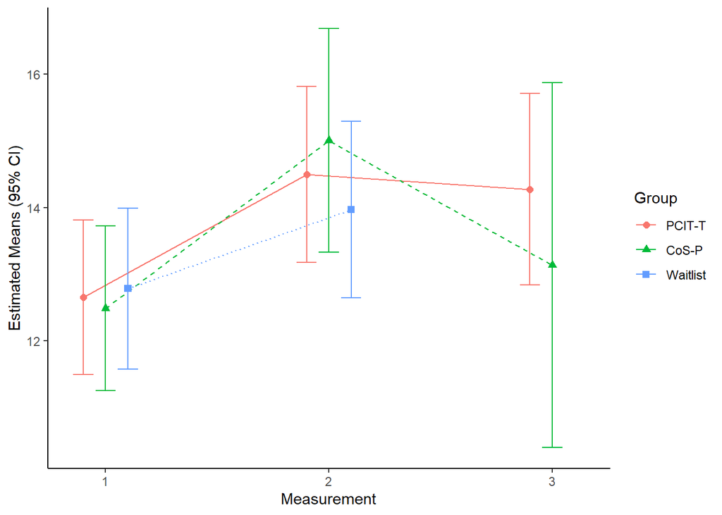

#### Hypothesis 1

We hypothesize that from baseline (‘T1’) to post-treatment/waitlist (‘T2’) there will be a gradient effect, whereby parent-child dyads who receive PCIT-T will show the greatest gains and parent-child dyads who receive no treatment will show the least gains. For the outcome, then, the null hypothesis is:

$H_0: \text {mean change}(\text{PCIT-T}) = \text {mean change}(\text{CoS-P}) = \text {mean change}(\text{Waitlist})$ $H_A: \text {mean change}(\text{PCIT-T}) > \text {mean change}(\text{CoS-P}) > \text {mean change}(\text{Waitlist})$

This is a joint hypothesis test.

First, confirming that the ordering of the means is as hypothesized:

```
## group = 1:
##  contrast estimate    SE    df t.ratio p.value
##  1 - 2      -1.838 0.666  78.8  -2.762  0.0194
##  1 - 3      -1.618 0.736  82.2  -2.198  0.0775
##  2 - 3       0.221 0.769  75.7   0.287  0.9557
##
## group = 2:
##  contrast estimate    SE    df t.ratio p.value
##  1 - 2      -2.517 0.849  97.3  -2.963  0.0106
##  1 - 3      -0.647 1.380 107.4  -0.469  0.8861
##  2 - 3       1.870 1.439  94.7   1.300  0.3989
##
## group = 3:
##  contrast estimate    SE    df t.ratio p.value
##  1 - 2      -1.182 0.678  80.9  -1.743  0.1956
##  1 - 3      nonEst    NA    NA      NA      NA
##  2 - 3      nonEst    NA    NA      NA      NA
##
## Results are averaged over the levels of: asdcase
## Degrees-of-freedom method: kenward-roger
## P value adjustment: tukey method for comparing a family of 3 estimates
```

```
##   (Intercept) asdcase1 group2 group3 time2 time3 group2:time2 group3:time2
## 1           0        0      0      0     0     0           -1            0
## 2           0        0      0      0     0     1            0            1
##   group2:time3
## 1            0
## 2            0
```

```
##
##   General Linear Hypotheses
##
## Linear Hypotheses:
##        Estimate
## 1 == 0  -0.6787
## 2 == 0   0.9616
##
## Global Test:
##        F DF1 DF2 Pr(>F)
## 1 0.5351   2 147 0.5868
```

pvalue>0.05. We have no evidence that there is a difference in the change over from Baseline to Post amongst the groups, such that PCITT showed the largest change, then COSP then Waitlist.

#### Hypothesis 2

There will be a gradient of size of change from T2 to T3 such that the change in the PCIT-T group > the change in the CoS-P group. This isn’t really a gradient; it’s just 1 hypothesis.

First, the change in PCITT and COSP from time 2 to time 3:

```
## group = 1:
##  contrast estimate    SE    df t.ratio p.value
##  1 - 2      -1.838 0.666  78.8  -2.762  0.0194
##  1 - 3      -1.618 0.736  82.2  -2.198  0.0775
##  2 - 3       0.221 0.769  75.7   0.287  0.9557
##
## group = 2:
##  contrast estimate    SE    df t.ratio p.value
##  1 - 2      -2.517 0.849  97.3  -2.963  0.0106
##  1 - 3      -0.647 1.380 107.4  -0.469  0.8861
##  2 - 3       1.870 1.439  94.7   1.300  0.3989
##
## group = 3:
##  contrast estimate    SE    df t.ratio p.value
##  1 - 2      -1.182 0.678  80.9  -1.743  0.1956
##  1 - 3      nonEst    NA    NA      NA      NA
##  2 - 3      nonEst    NA    NA      NA      NA
##
## Results are averaged over the levels of: asdcase
## Degrees-of-freedom method: kenward-roger
## P value adjustment: tukey method for comparing a family of 3 estimates
```

```
##
##   Simultaneous Tests for General Linear Hypotheses
##
## Fit: lmer(formula = outcome ~ asdcase + group * time + (1 | id), data = dat)
##
## Linear Hypotheses:
##        Estimate Std. Error z value Pr(>|z|)
## 1 == 0   -1.650      1.622  -1.017    0.309
## (Adjusted p values reported -- single-step method)
```

p>0.05.

#### Residuals

Assumptions of the model are met.

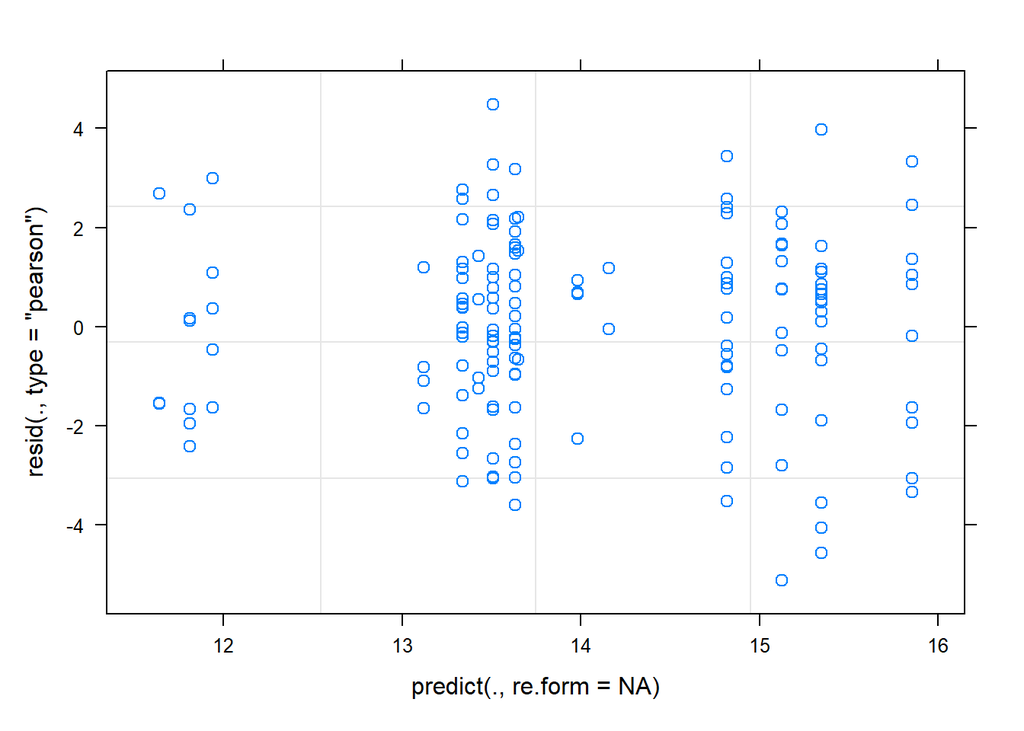

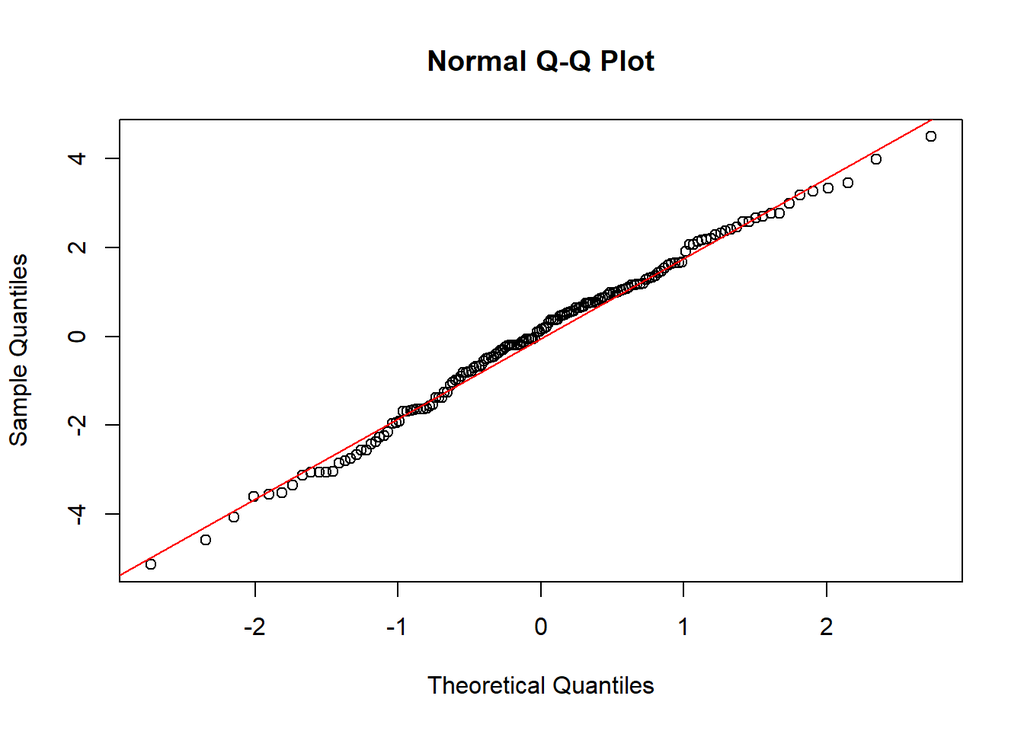

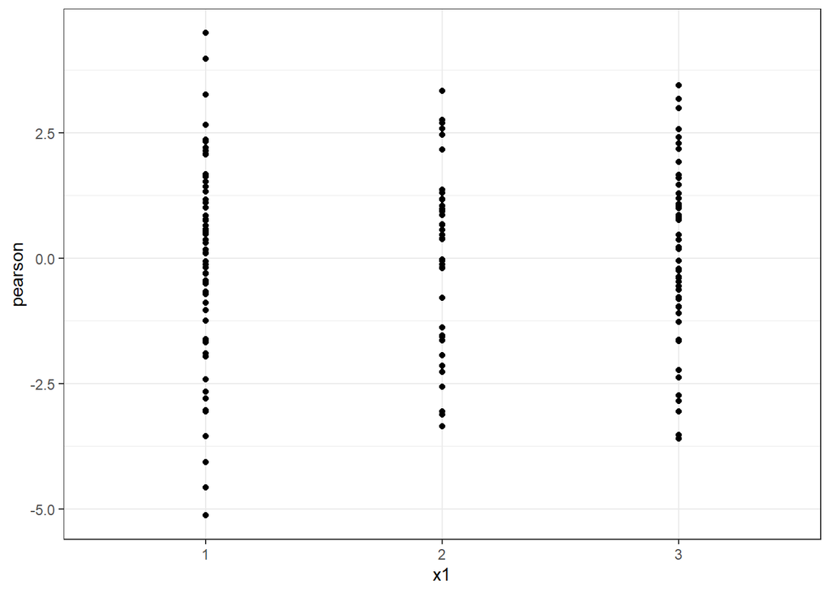

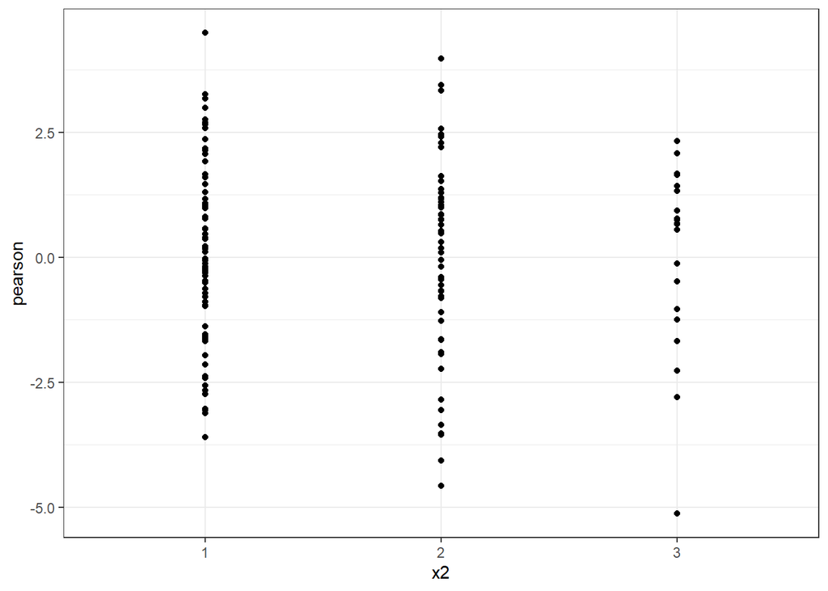

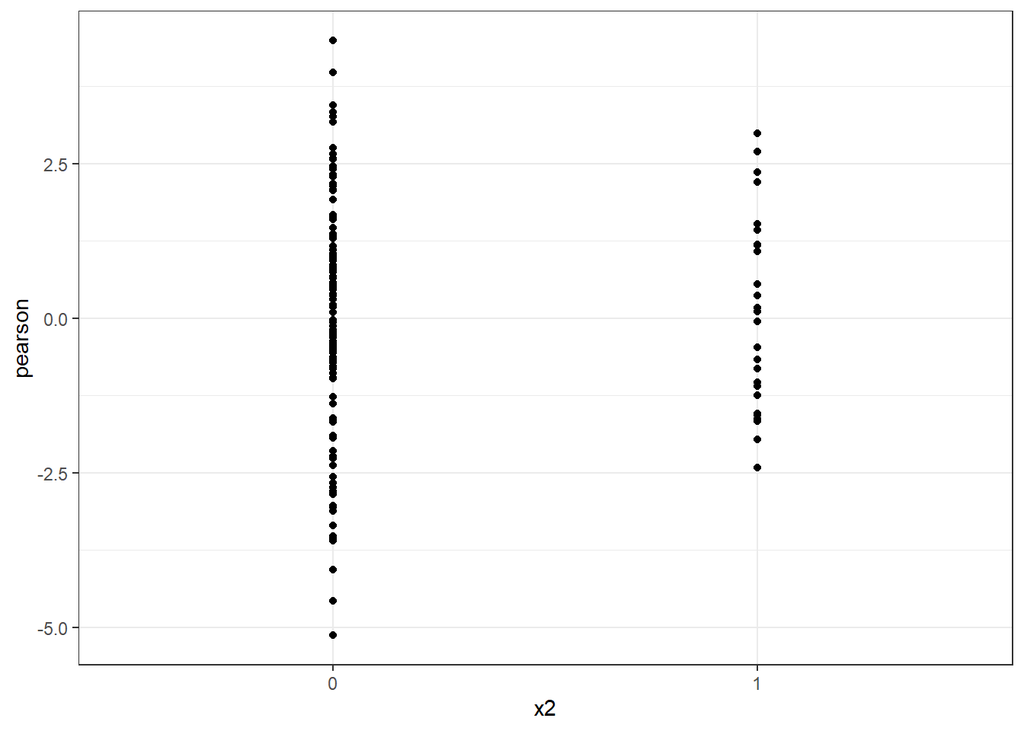

```r
rm(list = ls())
```